# R tutorial for analysing AMR phenotypic data

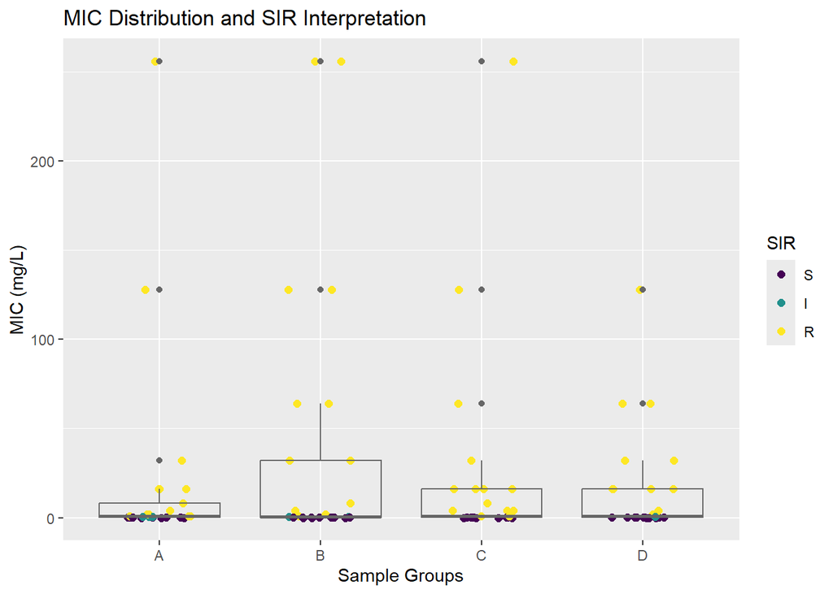

```r
# add a group
my_data$group <- rep(c("A", "B", "C", "D"), each = 25)

my_data$MIC <- as.numeric(my_data$MIC)

ggplot(my_data,
       aes(x = group, y = MIC, colour = SIR)) +
  geom_jitter(width = 0.2, size = 2) +
  geom_boxplot(fill = NA, colour = "grey40") +
  labs(title = "MIC Distribution and SIR Interpretation",
       x = "Sample Groups",
       y = "MIC (mg/L)")
```

Here is the list of geoms available through ggplot2.

```r
ls("package:ggplot2", pattern = "^geom_")
```

```
##  [1] "geom_abline"            "geom_area"              "geom_bar"
##  [4] "geom_bin_2d"            "geom_bin2d"             "geom_blank"
##  [7] "geom_boxplot"           "geom_col"               "geom_contour"
## [10] "geom_contour_filled"    "geom_count"             "geom_crossbar"
## [13] "geom_curve"             "geom_density"           "geom_density_2d"
## [16] "geom_density_2d_filled" "geom_density2d"         "geom_density2d_filled"
## [19] "geom_dotplot"           "geom_errorbar"          "geom_errorbarh"
## [22] "geom_freqpoly"          "geom_function"          "geom_hex"
## [25] "geom_histogram"         "geom_hline"             "geom_jitter"
## [28] "geom_label"             "geom_line"              "geom_linerange"
## [31] "geom_map"               "geom_path"              "geom_point"
## [34] "geom_pointrange"        "geom_polygon"           "geom_qq"
## [37] "geom_qq_line"           "geom_quantile"          "geom_raster"
## [40] "geom_rect"              "geom_ribbon"            "geom_rug"
## [43] "geom_segment"           "geom_sf"                "geom_sf_label"
## [46] "geom_sf_text"           "geom_smooth"            "geom_spoke"
## [49] "geom_step"              "geom_text"              "geom_tile"
## [52] "geom_violin"            "geom_vline"
```

There is also a range of aesthetics that can be adjusted:

```r
ggplot2:::.all_aesthetics
```

```
##  [1] "adj"        "alpha"      "angle"      "bg"         "cex"
##  [6] "col"        "color"      "colour"     "fg"         "fill"
## [11] "group"      "hjust"      "label"      "linetype"   "lower"
## [16] "lty"        "lwd"        "max"        "middle"     "min"
## [21] "pch"        "radius"     "sample"     "shape"      "size"
## [26] "srt"        "upper"      "vjust"      "weight"     "width"
## [31] "x"          "xend"       "xmax"       "xmin"       "xintercept"
## [36] "y"          "yend"       "ymax"       "ymin"       "yintercept"
## [41] "z"
```

For example, background colours (bg), rotating the angle of the text (angle), line type (lty) and width (lwd), colour transparency (alpha) can be adjusted.

$\\ \\$

**Plots for publications**

Below are some examples of more complex plots.

*Line graphs*

This example uses the ecoli dataset to generate a line graph to show the percentage of resistant *E. coli* over time. First the data is prepared.

```r
#Select columns of interest
ecoli_res <- ecoli3 %>%
  mutate(
    month = floor_date(date_collection, "month")  # Add new column called month and Convert date to first day of month
  ) %>%
  select(month, sample_source, sample_collection, AMP, TCY) #Select columns of interest

#Reshape data
ecoli_long <- ecoli_res %>%
  pivot_longer(cols = AMP:TCY, names_to = "antibiotic", values_to = "resistance") %>% #Reshape date into long format where antibiotics becomes a single column
  mutate(resistance = ifelse(as.numeric(resistance) == 3, 1, 0)) #Modify resistance column if level 3 (for R) set to 1, otherwise 0


#Summarise data for each month
res_summary <- ecoli_long %>%
  group_by(month, antibiotic) %>% #group by month and antibiotic
  summarise(percent_resistant = mean(resistance) * 100) #Generate a mean for each month
```

The data is now in a format to be plotted.

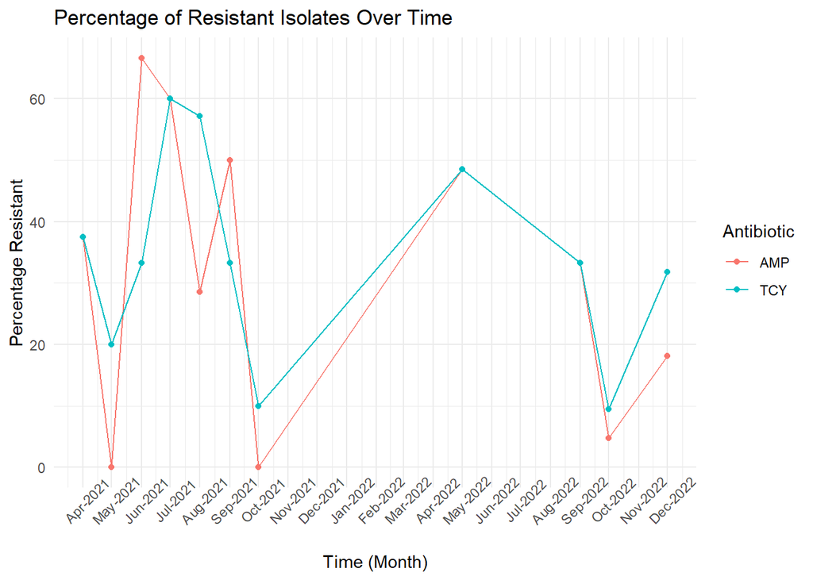

```r
ggplot(res_summary, aes(x = month, y = percent_resistant, color = antibiotic)) + #use the res_summary dataframe and plot month vs percent resistant
  geom_line() + #line graph
  geom_point() + #include points
  scale_x_date(date_labels = "%b-%Y",  date_breaks = "1 month") + #Use Month (%b)-Year(%Y) format for the labels and break by 1 month
  labs(
    title = "Percentage of Resistant Isolates Over Time",
    x = "Time (Month)",
    y = "Percentage Resistant",
    color = "Antibiotic") + #labels for title, x axis, y axis, legend
    theme_minimal() + #Use a minimal background theme which you can then build on
  theme(axis.text.x = element_text(angle = 45)) #theme() function is used for things that relate to the entire plot e.g. background colour. Change the element text of the x axis to a 45 C angle.
```

*Maps*

The example below illustrates how to generate a map using the rnaturalearth package and overlay it with prevalence data.

First reshape the data

```r
#Reshape data example using unite, example for me only.
ecoli_long <- ecoli_res %>%
  pivot_longer(cols = AMP:TCY, names_to = "antibiotic", values_to = "resistance") %>% #Reshape date into long format where antibiotics becomes a single column
  mutate(resistance = ifelse(as.numeric(resistance) == 3, 1, 0)) %>% #Modify resistance column if level 3 (for R) set to 1, otherwise 0
  unite(source_location, sample_source, location_name, sep = "_", remove = FALSE) #Generate new column source_location by uniting the sample-source and location_name columns
```

```r
res_location <- ecoli_long %>%
  filter(antibiotic == "AMP") %>%
  group_by(sample_source, antibiotic) %>%
  summarise(percent_resistant = mean(resistance) * 100)
head(res_location)
```

```
## # A tibble: 6 × 3
## # Groups:   sample_source [6]
##   sample_source antibiotic percent_resistant
##   <chr>         <chr>                  <dbl>
## 1 Chukha        AMP                     32.5
## 2 Dagana        AMP                     18.2
## 3 Samtse        AMP                     15.8
## 4 Sarpang       AMP                     33.3
## 5 Thimphu       AMP                     14.3
## 6 Tsirang       AMP                     44.4
```

Install and load the packages.

```r
#Install the packages
install.packages("devtools") # I guess you also need this
devtools::install_github("ropensci/rnaturalearthhires")
install.packages("rnaturalearth")
```

```r
#Load the libraries
library(rnaturalearth)
library(rnaturalearthhires)
```

Obtain the spatial data and merge with the reshaped data.

```r
#Obtain spatial data (sf object) for Bhutan using the ne_states() function
bhutan_map <- ne_states(country = "Bhutan", returnclass = "sf")

#Merging the map data with the perc_resistance data, note there must be matching columns.
map_data <- left_join(bhutan_map, res_location, by = c("name_sv" = "sample_source"))
```

Plot the data

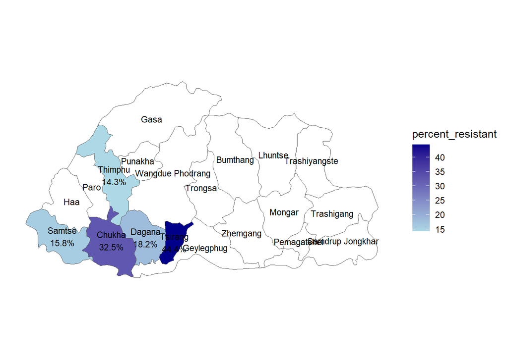

```r
ggplot(data = map_data) +
  geom_sf(aes(fill = percent_resistant)) +  # Plot a spatial object Fill regions based on resistance
  geom_sf_text(aes(label = ifelse(is.na(percent_resistant), name_sv,  # if NA label with name_sv (region)
                                  paste0(name_sv, "\n", round(percent_resistant, 1), "%")  # else label with name_sv and percent_resistant
                                  )), color = "black", size = 3) +  # Colors region names black size 3
  scale_fill_gradient(low = "lightblue", high = "darkblue", na.value = "white") +  # <- Closing parenthesis added here
  theme_minimal() +  # Use a minimal theme then add to it
  theme(axis.text = element_blank(),  # Remove axis labels
        axis.ticks = element_blank(),  # Remove axis ticks
        panel.grid = element_blank(),  # Remove panel grid
        axis.title = element_blank())  # Remove axis labels
```

Try removing some parts of the code above to see how the plot changes.

*Multi-panel box-plot*